# Machine Learning Project

**Your Name**:Bhargav Teja Jakku  
**Your G Number**: G01334185

```r
# Suppress dplyr summarise grouping warning messages
options(dplyr.summarise.inform = FALSE)

library(tidyverse)
library(tidymodels)
library(discrim)
credit_card_df <- readRDS(url('https://gmubusinessanalytics.netlify.app/data/credit_card_df.rds'))
```

# Data Analysis

In this section, you must think of at least 5 relevant questions that explore the relationship between `customer_status` and the other variables in the `credit_card_df` data set. The goal of your analysis should be discovering which variables drive the differences between customers who do and do not close their account.

You must answer each question and provide supporting data summaries with either a summary data frame (using `dplyr`/`tidyr`) or a plot (using `ggplot`) or both.

In total, you must have a minimum of 3 plots (created with `ggplot`) and 3 summary data frames (created with `dplyr`) for the exploratory data analysis section. Among the plots you produce, you must have at least 3 different types (ex. box plot, bar chart, histogram, scatter plot, etc…)

See the [Data Analysis Project](https://gmubusinessanalytics.netlify.app/data-analysis-project.html) for an example of a question answered with a summary table and plot.

**Note**: To add an R code chunk to any section of your project, you can use the keyboard shortcut `Ctrl` + `Alt` + `i` or the `insert` button at the top of your R project template notebook file.

# Question 1

**Question**: Is there a relationship between customer closing their account with their income?

## Summary Table

```r
credit_card_df %>% group_by(customer_status) %>%
                  summarise(n_status = n(),
                            min_salary = min(income),
                            avg_salary = mean(income),
                            max_salary = max(income),
                            sd_salary = sd(income))
```

| customer_status | n_status | min_salary | avg_salary | max_salary | sd_salary |
| --- | --- | --- | --- | --- | --- |
| closed_account | 2092 | 30198 | 61601.51 | 168522 | 33659.36 |
| active | 2535 | 30094 | 62842.83 | 166225 | 33306.29 |

## Data Visualization

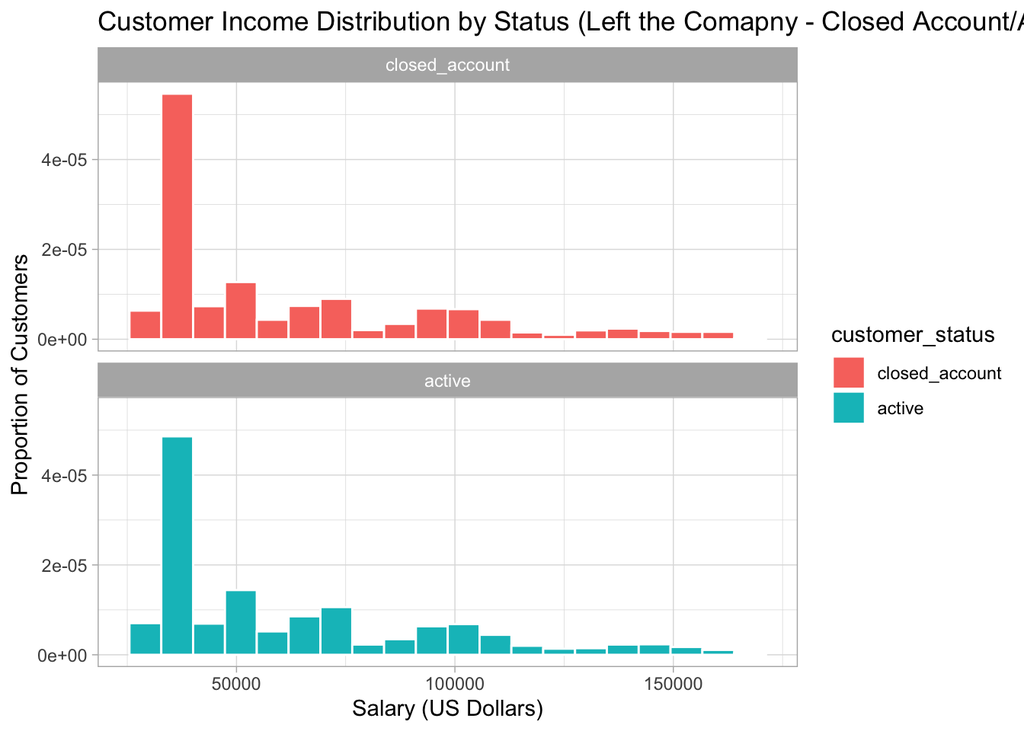

```r
ggplot(data =credit_card_df, aes(x = income, fill = customer_status)) +
   geom_histogram(aes(y = ..density..), color = "white", bins = 20) +
   facet_wrap(~ customer_status, nrow = 2) +
   labs(title = "Customer Income Distribution by Status (Left the Comapny - Closed Account/Active)",
           x = "Salary (US Dollars)", y = "Proportion of Customers")+theme_classic()+theme_light()
```